fossil

# Synthetic genetic interactions from a gene network, dug back up.

We rebuilt the lost program from the paper, put the 2009 yeast data back together and reran every experiment. 21 of 55 results were attempted: 0 exact, 4 agree, 4 partly, 1 inconclusive, 12 differ. The method runs; its curves do not come back.

See every result

## Fig. 2

Fig. 2. ROC curves of SSL (blue) and SVM (red) with 20% of the gene pairs unlabelled (5-fold cross-validation).

Differs

Published

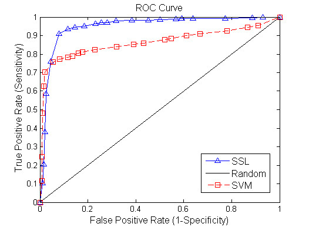

Our run

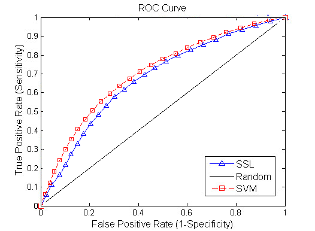

**Fig. 2, ROC of SSL and SVM, 20% unlabelled**

3.4% within 2.0 px, Differs

Not reproduced with the network the Methods describe (protein interactions and complexes): areas under the ROC curve 0.675 to 0.645 for SSL and 0.705 to 0.678 for SVM; the published curves enclose 0.963, 0.912 and 0.875 (SSL) and 0.878, 0.818 and 0.74 (SVM), read from Figs 2-4. The published level comes back once BioGRID's genetic interactions are in the network (Fig. 3 setting: SSL 0.859, SVM 0.9096 without Tong 2004's own rows, 0.89 and 0.9587 with them); these edges carry the SGI labels into the features. Open: the authors' exact network, and the order of the two classifiers (SVM stays ahead of SSL in every variant we ran).

## Fig. 3

Fig. 3. ROC curves of SSL and SVM with 50% unlabelled (2-fold).

Inconclusive

Published

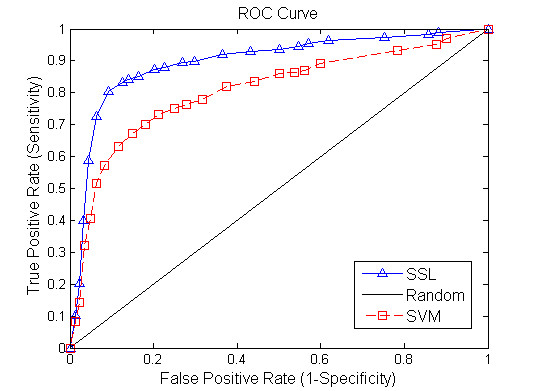

Our run

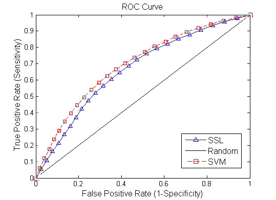

**Fig. 3, ROC of SSL and SVM, 50% unlabelled**

6.3% within 2.0 px, Inconclusive

Not reproduced with the network the Methods describe (protein interactions and complexes): areas under the ROC curve 0.675 to 0.645 for SSL and 0.705 to 0.678 for SVM; the published curves enclose 0.963, 0.912 and 0.875 (SSL) and 0.878, 0.818 and 0.74 (SVM), read from Figs 2-4. The published level comes back once BioGRID's genetic interactions are in the network (Fig. 3 setting: SSL 0.859, SVM 0.9096 without Tong 2004's own rows, 0.89 and 0.9587 with them); these edges carry the SGI labels into the features. Open: the authors' exact network, and the order of the two classifiers (SVM stays ahead of SSL in every variant we ran).

## Fig. 4

Fig. 4. ROC curves of SSL and SVM with 80% unlabelled (trained on one fold of five).

Differs

Published

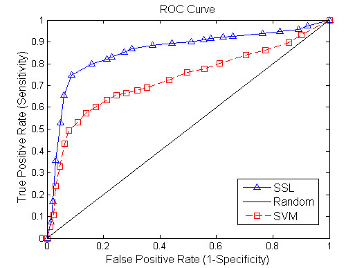

Our run

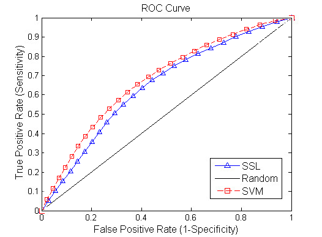

**Fig. 4, ROC of SSL and SVM, 80% unlabelled**

9.1% within 2.0 px, Differs

Not reproduced with the network the Methods describe (protein interactions and complexes): areas under the ROC curve 0.675 to 0.645 for SSL and 0.705 to 0.678 for SVM; the published curves enclose 0.963, 0.912 and 0.875 (SSL) and 0.878, 0.818 and 0.74 (SVM), read from Figs 2-4. The published level comes back once BioGRID's genetic interactions are in the network (Fig. 3 setting: SSL 0.859, SVM 0.9096 without Tong 2004's own rows, 0.89 and 0.9587 with them); these edges carry the SGI labels into the features. Open: the authors' exact network, and the order of the two classifiers (SVM stays ahead of SSL in every variant we ran).

## Fig. 5

Fig. 5. ROC curves of SSL on the weighted functional gene network (blue) and on the binary network (red), 50% unlabelled. The published legend reads SSL, Random, SVM.

Partly agrees

Published

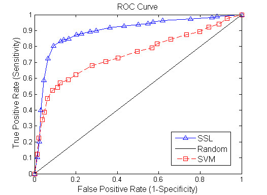

Our run

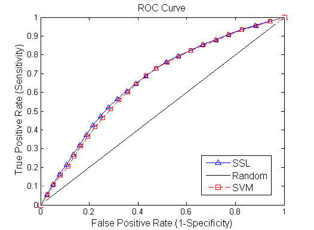

**Fig. 5, ROC of SSL on the weighted FGN and on the binary network, 50% unlabelled**

10.2% within 2.0 px, Partly agrees

Both curves sit far below the published ones (SSL area under the ROC curve 0.664 weighted, 0.656 binary; read from Fig. 5, 0.912 and 0.759). The weighted curve stays above the binary one, by a small margin. The published legend reads SSL / Random / SVM although the caption compares weighted and binary networks.

## Fig. 6

Fig. 6. Densities of the absolute difference of (a) degree, (b) closeness, (c) betweenness and (d) clustering coefficient across a gene pair, SGI pairs (blue) and non-SGI pairs (red dashed), weighted network.

Differs

Published

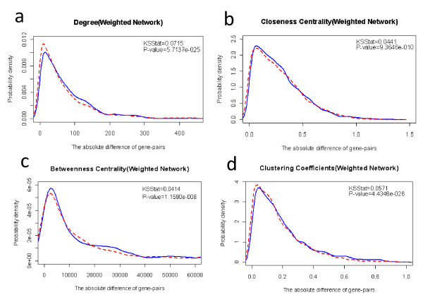

Our run

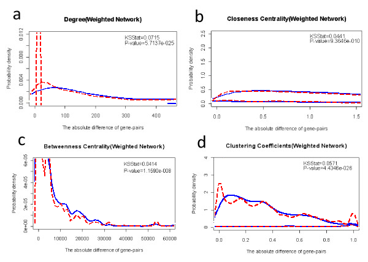

**Fig. 6a, absolute difference of degree (weighted network)**

7.4% within 2.0 px, Differs

**Fig. 6b, absolute difference of closeness (weighted network)**

3.0% within 2.0 px, Differs

**Fig. 6c, absolute difference of betweenness (weighted network)**

15.4% within 2.0 px, Differs

**Fig. 6d, absolute difference of clustering coefficient (weighted network)**

10.5% within 2.0 px, Partly agrees

**Fig. 6, KSStat and P-value printed in each panel**

0 of 8 values, Differs

Our weighted degree values are on a larger scale than the paper's (99th percentile of the SGI pairs' absolute difference 2,218 against a published axis that ends near 460), so our densities spread past the published axes. Our weighted closeness values are on a larger scale than the paper's (99th percentile of the SGI pairs' absolute difference 3.981 against a published axis that ends near 1.5), so our densities spread past the published axes. Our weighted betweenness values are on a larger scale than the paper's (99th percentile of the SGI pairs' absolute difference 1.164e+05 against a published axis that ends near 6e+04), so our densities spread past the published axes. Our clustering coefficients span the published axis (0 to 1), but the densities have another shape: ours are flatter and bimodal where the paper's peak near 0.05. The pairs and the network behind the panel are not the paper's (see Table 1). The paper's P-values imply about 5,531 (weighted) to 5,782 (binary) effective pairs per test; ours are 3,029 (all 3054 SGI pairs in the network against 376654 tested non-SGI pairs). The pairs and network behind Table 1 are not stated and are not the ones we can rebuild.

## Every result

Every figure, table and number in the paper, with the verdict check_results.py computes from our run.

Result

Verdict

Measure

Why

Fig. 1, workflow schematic

Not attempted

A diagram of the workflow; nothing is computed.

Abstract and Results: sensitivity 92% at specificity 91% (TPR 0.92 at FPR 0.09)

Differs

0 of 1 values

- Best SSL sensitivity at 1 - specificity 0.09: paper 0.92, ours **0.20**

Not reproduced with the network the Methods describe (protein interactions and complexes): areas under the ROC curve 0.675 to 0.645 for SSL and 0.705 to 0.678 for SVM; the published curves enclose 0.963, 0.912 and 0.875 (SSL) and 0.878, 0.818 and 0.74 (SVM), read from Figs 2-4. The published level comes back once BioGRID's genetic interactions are in the network (Fig. 3 setting: SSL 0.859, SVM 0.9096 without Tong 2004's own rows, 0.89 and 0.9587 with them); these edges carry the SGI labels into the features. Open: the authors' exact network, and the order of the two classifiers (SVM stays ahead of SSL in every variant we ran).

Fig. 2, ROC of SSL and SVM, 20% unlabelled

Differs

3.4% within 2.0 px

Not reproduced with the network the Methods describe (protein interactions and complexes): areas under the ROC curve 0.675 to 0.645 for SSL and 0.705 to 0.678 for SVM; the published curves enclose 0.963, 0.912 and 0.875 (SSL) and 0.878, 0.818 and 0.74 (SVM), read from Figs 2-4. The published level comes back once BioGRID's genetic interactions are in the network (Fig. 3 setting: SSL 0.859, SVM 0.9096 without Tong 2004's own rows, 0.89 and 0.9587 with them); these edges carry the SGI labels into the features. Open: the authors' exact network, and the order of the two classifiers (SVM stays ahead of SSL in every variant we ran).

Fig. 3, ROC of SSL and SVM, 50% unlabelled

Inconclusive

6.3% within 2.0 px

Not reproduced with the network the Methods describe (protein interactions and complexes): areas under the ROC curve 0.675 to 0.645 for SSL and 0.705 to 0.678 for SVM; the published curves enclose 0.963, 0.912 and 0.875 (SSL) and 0.878, 0.818 and 0.74 (SVM), read from Figs 2-4. The published level comes back once BioGRID's genetic interactions are in the network (Fig. 3 setting: SSL 0.859, SVM 0.9096 without Tong 2004's own rows, 0.89 and 0.9587 with them); these edges carry the SGI labels into the features. Open: the authors' exact network, and the order of the two classifiers (SVM stays ahead of SSL in every variant we ran).

Fig. 4, ROC of SSL and SVM, 80% unlabelled

Differs

9.1% within 2.0 px

Not reproduced with the network the Methods describe (protein interactions and complexes): areas under the ROC curve 0.675 to 0.645 for SSL and 0.705 to 0.678 for SVM; the published curves enclose 0.963, 0.912 and 0.875 (SSL) and 0.878, 0.818 and 0.74 (SVM), read from Figs 2-4. The published level comes back once BioGRID's genetic interactions are in the network (Fig. 3 setting: SSL 0.859, SVM 0.9096 without Tong 2004's own rows, 0.89 and 0.9587 with them); these edges carry the SGI labels into the features. Open: the authors' exact network, and the order of the two classifiers (SVM stays ahead of SSL in every variant we ran).

Results: SSL outperforms SVM in almost all the range of threshold (Figs 2-4)

Differs

0 of 3 values

- Fig. 2: SSL at or above SVM over at least 90% of the FPR range: paper yes, ours **no**
- Fig. 3: SSL at or above SVM over at least 90% of the FPR range: paper yes, ours **no**
- Fig. 4: SSL at or above SVM over at least 90% of the FPR range: paper yes, ours **no**

On our run SVM is at or above SSL over most of the range at every training size, and it stays ahead in every variant we ran, including the networks with genetic interactions that bring the AUC back to the published level.

Results: at 20% unlabelled SVM is slightly better at the start of the ROC curve and SSL elsewhere

Partly agrees

1 of 2 values

- SVM above SSL at FPR up to 0.05: paper yes, ours **yes**
- SSL at or above SVM at FPR above 0.05 (90% of the range): paper yes, ours **no**

SVM is ahead at the start of our Fig. 2 curve, as the paper says, but also over the rest of it.

Results: SSL much better than SVM with 80% unlabelled; its advantage grows as training sets shrink

Differs

0 of 2 values

- Fig. 4: SSL area under the ROC curve above SVM's by more than 0.05: paper yes, ours **no**
- SSL's lead over SVM larger at 80% than at 20% unlabelled: paper yes, ours **no**

SSL minus SVM area under the ROC curve on our run: -0.0301 (20% unlabelled), -0.0293 (50%), -0.0328 (80%). SVM leads at every size, with or without genetic interactions in the network.

Fig. 5, ROC of SSL on the weighted FGN and on the binary network, 50% unlabelled

Partly agrees

10.2% within 2.0 px

Both curves sit far below the published ones (SSL area under the ROC curve 0.664 weighted, 0.656 binary; read from Fig. 5, 0.912 and 0.759). The weighted curve stays above the binary one, by a small margin. The published legend reads SSL / Random / SVM although the caption compares weighted and binary networks.

Results: the weighted network beats the binary network in almost all the range of threshold (Fig. 5)

Agrees

2 of 2 values

- Weighted FGN at or above the binary network over at least 90% of the FPR range: paper yes, ours **yes**
- Weighted FGN area under the ROC curve above the binary network's: paper yes, ours **yes**

Fig. 6a, absolute difference of degree (weighted network)

Differs

7.4% within 2.0 px

Our weighted degree values are on a larger scale than the paper's (99th percentile of the SGI pairs' absolute difference 2,218 against a published axis that ends near 460), so our densities spread past the published axes.

Fig. 6b, absolute difference of closeness (weighted network)

Differs

3.0% within 2.0 px

Our weighted closeness values are on a larger scale than the paper's (99th percentile of the SGI pairs' absolute difference 3.981 against a published axis that ends near 1.5), so our densities spread past the published axes.

Fig. 6c, absolute difference of betweenness (weighted network)

Differs

15.4% within 2.0 px

Our weighted betweenness values are on a larger scale than the paper's (99th percentile of the SGI pairs' absolute difference 1.164e+05 against a published axis that ends near 6e+04), so our densities spread past the published axes.

Fig. 6d, absolute difference of clustering coefficient (weighted network)

Partly agrees

10.5% within 2.0 px

Our clustering coefficients span the published axis (0 to 1), but the densities have another shape: ours are flatter and bimodal where the paper's peak near 0.05. The pairs and the network behind the panel are not the paper's (see Table 1).

Fig. 6, KSStat and P-value printed in each panel

Differs

0 of 8 values

- Fig. 6a KSStat: paper 0.0715, ours **0.0444**
- Fig. 6a P-value (x 1E-25): paper 5.7137, ours **1.24632e+20**
- Fig. 6b KSStat: paper 0.0441, ours **0.0427**
- Fig. 6b P-value (x 1E-10): paper 9.3646, ours **309319**
- Fig. 6c KSStat: paper 0.0414, ours **0.0903**
- Fig. 6c P-value (x 1E-08): paper 1.1590, ours **5.78922e-14**
- Fig. 6d KSStat: paper 0.0571, ours **0.0666**
- Fig. 6d P-value (x 1E-26): paper 4.4346, ours **3.98738e+14**

The paper's P-values imply about 5,531 (weighted) to 5,782 (binary) effective pairs per test; ours are 3,029 (all 3054 SGI pairs in the network against 376654 tested non-SGI pairs). The pairs and network behind Table 1 are not stated and are not the ones we can rebuild.

Table 1, KS statistic and P-value for 8 pair characteristics, binary and weighted network

Differs

0 of 32 values

The paper's P-values imply about 5,531 (weighted) to 5,782 (binary) effective pairs per test; ours are 3,029 (all 3054 SGI pairs in the network against 376654 tested non-SGI pairs). The pairs and network behind Table 1 are not stated and are not the ones we can rebuild.

Discussion: all Table 1 P-values are below 0.05

Differs

0 of 1 values

- All Table 1 P-values below 0.05: paper yes, ours **no**

The claim does not hold in the paper's own Table 1 (binary average degree, P = 0.9). On our run the weighted average closeness is not significant either (P = 0.125).

Discussion: SGI pairs tend to have higher average degree and higher average closeness (medians)

Agrees

2 of 2 values

- SGI pairs have the higher average degree (weighted FGN): paper yes, ours **yes**
- SGI pairs have the higher average closeness (weighted FGN): paper yes, ours **yes**

Both medians are higher for SGI pairs, as the paper says; on our run the closeness difference is small and not significant (weighted average closeness P = 0.125).

Discussion: the P-values of all properties are much smaller in the weighted network than in the binary one

Differs

0 of 1 values

- Weighted-network P below the binary network's for all 8 characteristics: paper yes, ours **no**

The claim fails in one of the 8 rows of the paper's own Table 1 (absolute difference of closeness: 9.365E-10 weighted against 1.00E-17 binary). On our run the weighted P is the smaller in 1 of 8 rows.

Arithmetic check: the Discussion's claims recomputed from the paper's own Table 1 and Fig. 6 (the paper's numbers, not our run)

Agrees

Table 2, list of the 10 network properties

Not attempted

A list of the properties used, with references; nothing is computed. Our implementation of each is in package/src/fgnssl/network.py.

Methods: data counts (Tong 2004 screen, PPI, complexes, expression conditions)

Partly agrees

2 of 8 values

- Tong 2004 query genes: paper 132, ours **125**
- Deletion-array genes (about 4,700): paper 4700, ours **4747**
- Tested pairs (about 650,000): paper 650000, ours **586472**
- Synthetic lethal and sick interactions (about 4,000): paper 4000, ours **3411**
- PPI interactions: paper 12990, ours **13007**
- PPI proteins: paper 4478, ours **3915**
- Complex interactions (about 49,000): paper 49000, ours **48129**
- Expression conditions: paper 64, ours **54**

Additional file 1, Fig. S1

Not attempted

Not drawn. Densities of the same properties as Fig. 6 (average and absolute difference, binary and weighted network). Their values are computed (output/densities.json) and their KS numbers are Table 1's; Fig. 6 shows our weighted values on a larger scale than the paper's, so a pixel comparison would repeat that result.

Additional file 1, Fig. S2

Not attempted

Not drawn. Densities of the same properties as Fig. 6 (average and absolute difference, binary and weighted network). Their values are computed (output/densities.json) and their KS numbers are Table 1's; Fig. 6 shows our weighted values on a larger scale than the paper's, so a pixel comparison would repeat that result.

Additional file 1, Fig. S3

Not attempted

Not drawn. Densities of the same properties as Fig. 6 (average and absolute difference, binary and weighted network). Their values are computed (output/densities.json) and their KS numbers are Table 1's; Fig. 6 shows our weighted values on a larger scale than the paper's, so a pixel comparison would repeat that result.

Additional file 1, Fig. S4

Not attempted

Not drawn. Densities of the same properties as Fig. 6 (average and absolute difference, binary and weighted network). Their values are computed (output/densities.json) and their KS numbers are Table 1's; Fig. 6 shows our weighted values on a larger scale than the paper's, so a pixel comparison would repeat that result.

Additional file 1, Fig. S5

Not attempted

Not drawn. Densities of the same properties as Fig. 6 (average and absolute difference, binary and weighted network). Their values are computed (output/densities.json) and their KS numbers are Table 1's; Fig. 6 shows our weighted values on a larger scale than the paper's, so a pixel comparison would repeat that result.

Additional file 1, Fig. S6

Not attempted

Not drawn. Densities of the same properties as Fig. 6 (average and absolute difference, binary and weighted network). Their values are computed (output/densities.json) and their KS numbers are Table 1's; Fig. 6 shows our weighted values on a larger scale than the paper's, so a pixel comparison would repeat that result.

Additional file 1, Fig. S7

Not attempted

Not drawn. Densities of the same properties as Fig. 6 (average and absolute difference, binary and weighted network). Their values are computed (output/densities.json) and their KS numbers are Table 1's; Fig. 6 shows our weighted values on a larger scale than the paper's, so a pixel comparison would repeat that result.

Additional file 1, Fig. S8

Not attempted

Not drawn. Densities of the same properties as Fig. 6 (average and absolute difference, binary and weighted network). Their values are computed (output/densities.json) and their KS numbers are Table 1's; Fig. 6 shows our weighted values on a larger scale than the paper's, so a pixel comparison would repeat that result.

Additional file 1, Fig. S9

Not attempted

Not drawn. Densities of the same properties as Fig. 6 (average and absolute difference, binary and weighted network). Their values are computed (output/densities.json) and their KS numbers are Table 1's; Fig. 6 shows our weighted values on a larger scale than the paper's, so a pixel comparison would repeat that result.

Additional file 1, Fig. S10

Not attempted

Not drawn. Densities of the same properties as Fig. 6 (average and absolute difference, binary and weighted network). Their values are computed (output/densities.json) and their KS numbers are Table 1's; Fig. 6 shows our weighted values on a larger scale than the paper's, so a pixel comparison would repeat that result.

Additional file 1, Fig. S11

Not attempted

Not drawn. Densities of the same properties as Fig. 6 (average and absolute difference, binary and weighted network). Their values are computed (output/densities.json) and their KS numbers are Table 1's; Fig. 6 shows our weighted values on a larger scale than the paper's, so a pixel comparison would repeat that result.

Additional file 1, Fig. S12

Not attempted

Not drawn. Densities of the same properties as Fig. 6 (average and absolute difference, binary and weighted network). Their values are computed (output/densities.json) and their KS numbers are Table 1's; Fig. 6 shows our weighted values on a larger scale than the paper's, so a pixel comparison would repeat that result.

Additional file 1, Fig. S13

Not attempted

Not drawn. Densities of the same properties as Fig. 6 (average and absolute difference, binary and weighted network). Their values are computed (output/densities.json) and their KS numbers are Table 1's; Fig. 6 shows our weighted values on a larger scale than the paper's, so a pixel comparison would repeat that result.

Additional file 1, Fig. S14

Not attempted

Not drawn. Densities of the same properties as Fig. 6 (average and absolute difference, binary and weighted network). Their values are computed (output/densities.json) and their KS numbers are Table 1's; Fig. 6 shows our weighted values on a larger scale than the paper's, so a pixel comparison would repeat that result.

Additional file 1, Fig. S15

Not attempted

Not drawn. Densities of the same properties as Fig. 6 (average and absolute difference, binary and weighted network). Their values are computed (output/densities.json) and their KS numbers are Table 1's; Fig. 6 shows our weighted values on a larger scale than the paper's, so a pixel comparison would repeat that result.

Additional file 1, Fig. S16

Not attempted

Not drawn. Densities of the same properties as Fig. 6 (average and absolute difference, binary and weighted network). Their values are computed (output/densities.json) and their KS numbers are Table 1's; Fig. 6 shows our weighted values on a larger scale than the paper's, so a pixel comparison would repeat that result.

Additional file 1, Fig. S17

Not attempted

Not drawn. Empirical CDFs of the properties of Figs S1-S16 (quantiles in output/densities.json); the same scale difference as Fig. 6 applies.

Additional file 1, Fig. S18

Not attempted

Not drawn. Empirical CDFs of the properties of Figs S1-S16 (quantiles in output/densities.json); the same scale difference as Fig. 6 applies.

Additional file 1, Fig. S19

Not attempted

Not drawn. Empirical CDFs of the properties of Figs S1-S16 (quantiles in output/densities.json); the same scale difference as Fig. 6 applies.

Additional file 1, Fig. S20

Not attempted

Not drawn. Empirical CDFs of the properties of Figs S1-S16 (quantiles in output/densities.json); the same scale difference as Fig. 6 applies.

Additional file 1, Fig. S21

Not attempted

Not drawn. Empirical CDFs of the properties of Figs S1-S16 (quantiles in output/densities.json); the same scale difference as Fig. 6 applies.

Additional file 1, Fig. S22

Not attempted

Not drawn. Empirical CDFs of the properties of Figs S1-S16 (quantiles in output/densities.json); the same scale difference as Fig. 6 applies.

Additional file 1, Fig. S23

Not attempted

Not drawn. Empirical CDFs of the properties of Figs S1-S16 (quantiles in output/densities.json); the same scale difference as Fig. 6 applies.

Additional file 1, Fig. S24

Not attempted

Not drawn. Empirical CDFs of the properties of Figs S1-S16 (quantiles in output/densities.json); the same scale difference as Fig. 6 applies.

Additional file 1, Fig. S25

Not attempted

Not drawn. Empirical CDFs of the properties of Figs S1-S16 (quantiles in output/densities.json); the same scale difference as Fig. 6 applies.

Additional file 1, Fig. S26

Not attempted

Not drawn. Empirical CDFs of the properties of Figs S1-S16 (quantiles in output/densities.json); the same scale difference as Fig. 6 applies.

Additional file 1, Fig. S27

Not attempted

Not drawn. Empirical CDFs of the properties of Figs S1-S16 (quantiles in output/densities.json); the same scale difference as Fig. 6 applies.

Additional file 1, Fig. S28

Not attempted

Not drawn. Empirical CDFs of the properties of Figs S1-S16 (quantiles in output/densities.json); the same scale difference as Fig. 6 applies.

Additional file 1, Fig. S29

Not attempted

Not drawn. Empirical CDFs of the properties of Figs S1-S16 (quantiles in output/densities.json); the same scale difference as Fig. 6 applies.

Additional file 1, Fig. S30

Not attempted

Not drawn. Empirical CDFs of the properties of Figs S1-S16 (quantiles in output/densities.json); the same scale difference as Fig. 6 applies.

Additional file 1, Fig. S31

Not attempted

Not drawn. Empirical CDFs of the properties of Figs S1-S16 (quantiles in output/densities.json); the same scale difference as Fig. 6 applies.

Additional file 1, Fig. S32

Not attempted

Not drawn. Empirical CDFs of the properties of Figs S1-S16 (quantiles in output/densities.json); the same scale difference as Fig. 6 applies.

Python package fgnssl and its tutorial

Agrees

Main claim, SSL beats SVM and reaches sensitivity 0.92 at 1 minus specificity 0.09: differs. With the network the Methods describe (protein interactions and complexes) SVM leads at every training size and the best SSL sensitivity at 0.09 is 0.20. The published accuracy comes back once BioGRID's genetic interactions are in the network, and these carry the SGI labels into it (Fig. 3 setting: SSL 0.859, SVM 0.9096); SVM still leads. The paper's pair-level cross-validation also lets gene identity alone reach 0.8874. Weighted beats binary: agrees, by a small margin. Two Discussion claims fail in the paper's own Table 1.

## What came back

**Data, in part**

SGD's copy of BioGRID of 2009-12-19: 48129 complex edges against about 49,000 and 4747 deletion-array genes against about 4,700 agree; 3411 Tong SGI pairs (about 4,000), 125 query genes (132) and 3915 PPI proteins (4,478) do not.

**Method**

Divisive correlation clustering, eq. 2 weights, the 10 properties and 18 features, label spreading and an RBF SVM, as the package fgnssl.

**Weighted against binary**

SSL area under the ROC curve 0.664 on the weighted network, 0.656 on the binary one: the paper's order, by a small margin.

**SGI pairs sit higher**

SGI pairs have the higher median average degree and closeness, as the Discussion says; the closeness difference is not significant on our run.

**Why the paper's numbers are so high**

With BioGRID's genetic interactions in the network the AUC reaches the published level; 1899 of the 3411 Tong SGI pairs are themselves genetic-interaction edges reported by other papers. Gene identity alone reaches 0.8874 under the paper's pair-level cross-validation.

## What stayed buried

- The ROC curves with the network the Methods describe. SSL reaches 0.675 to 0.645 under the curve and SVM 0.705 to 0.678; the published SSL curves enclose 0.875 to 0.963. Adding BioGRID's genetic interactions, which hold many of the SGI labels, brings them to 0.859 (SSL) and 0.9096 (SVM) at 50% unlabelled.
- SSL over SVM. SVM leads at every training size, with or without genetic interactions in the network.
- Table 1 and Fig. 6. Our KS statistics differ; the paper's P-values imply about 5,531 (weighted) to 5,782 (binary) pairs per test, ours 3,029.
- Eisen's 1998 heat-shock time course; the paper's protein-interaction filter, SSL settings, SVM grid and seeds.

Main claim, SSL beats SVM and reaches sensitivity 0.92 at 1 minus specificity 0.09: differs. With the network the Methods describe (protein interactions and complexes) SVM leads at every training size and the best SSL sensitivity at 0.09 is 0.20. The published accuracy comes back once BioGRID's genetic interactions are in the network, and these carry the SGI labels into it (Fig. 3 setting: SSL 0.859, SVM 0.9096); SVM still leads. The paper's pair-level cross-validation also lets gene identity alone reach 0.8874. Weighted beats binary: agrees, by a small margin. Two Discussion claims fail in the paper's own Table 1.

## What we matched

What we fixed to make the run, and where it came from.

**Protein interactions**

Two-hybrid and Affinity Capture-Western, 13007 interactions (paper 12,990), the closest interpretable filter.

**Expression**

54 conditions from SGD's processed sets (paper 64).

**Non-SGI pairs**

Tong query genes by the non-essential deletion array, 586472 tested pairs.

**SSL**

alpha 0.99, sigma chosen on the training labels.

**SVM**

RBF kernel, C and gamma by grid search on the training folds.